# Practical Machine Learning: Course Project Writeup

Anand Akella

September 26, 2015

Project Background: The goal of this project is to quantify personal activity data collected from accelerometers such as Jawbone Up, Nike FuelBand, and Fitbit of 6 participants. These accelerometers and other monitoring devices placed on belt, forearm, arm, and dumbell collect data to help quantify patterns and habits.Participants were asked to perform barbell lifts correctly and incorrectly in 5 different ways.More information is available from the website: http://groupware.les.inf.puc-rio.br/har (see the section on the Weight Lifting Exercise Dataset).

Download and Prepare Datasets: Create a folder named Practical Machine Learning on desktop and set it as Working Directory. Download and save datasets into this working directory.

The training data for this project are available here: https://d396qusza40orc.cloudfront.net/predmachlearn/pml-training.csv

The test data are available here: https://d396qusza40orc.cloudfront.net/predmachlearn/pml-testing.csv

```r
# Load necessary libraries - install any unavailable packages
# using install.packages("packagename") command. Install "caret" with dependencies=TRUE
library(caret)
```

```r
library(rpart)
library(rpart.plot)
library(RColorBrewer)
library(rattle)
library(randomForest)
#install.packages('e1071', dependencies=TRUE)
```

```r
# files downloaded to the working directory and saved
trainData <- read.csv("pml-training.csv")
testData  <- read.csv("pml-testing.csv")
set.seed(4174) # set seed to load same seed for reproducibility
```

Select only those variables that have no missing values or NA from the actual test data

```r
valmissVariables <- sapply(testData,
                           function (x) any(is.na(x) | x == ""))# variables missing values or having NA
# all other variables for belt, forearm, arm and dumbell can be classified as predictor Candidate
predCandidate <- !valmissVariables & grepl("belt|[^(fore)]arm|dumbbell|forearm",names(valmissVariables))
predCandidates <- names(valmissVariables)[predCandidate] # complete set of predictor variables
# subset trainData Predictor candidates to include "classe" as output
includeVariables <- c("classe",predCandidates)
trainData <- trainData[includeVariables] # subset of traindata to include only the include variables
trainData$classe <- factor(trainData$classe)# convert classe into a factor
```

Split the Training Dataset into two sets with 60% training and 40% probing dataset

```r
trainSplit   <- createDataPartition(y=trainData$classe, p=0.6, list=FALSE)
trainDataSet <- trainData[trainSplit, ]  # 60% training dataset
probeDataSet <- trainData[-trainSplit, ] # 40% probe dataset
```

Check for Near Zero Variance in any of the variables. Since any variables that have NA or missing values have been excluded the test should yield no variables with near zero variance

```r
nzv <- nearZeroVar(trainDataSet, saveMetrics=TRUE)
if (any(nzv$nzv)) nzv else message("No variables with near zero variance")
```

```
## No variables with near zero variance
```

Prediction ML Algorithms:

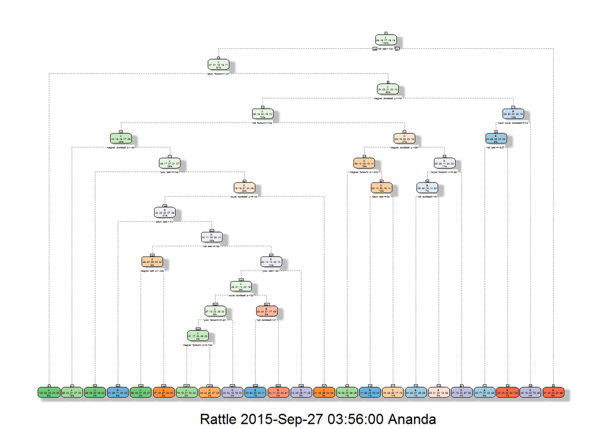

```r
modelFit1 <- rpart(classe ~ ., data=trainDataSet, method="class")# model fit
fancyRpartPlot(modelFit1) # plot the decision tree
```

```r
#Predicting
predictionFit1 <- predict(modelFit1, probeDataSet, type = "class")
confusionMatrix(predictionFit1, probeDataSet$classe)# confusion matrix to test final prediction results
```

```
## Confusion Matrix and Statistics
##
##           Reference
## Prediction    A    B    C    D    E
##          A 1990  307   25  112   63
##          B   56  848   70   26   77
##          C   58  150 1108  215  200
##          D   81  108   87  811   87
##          E   47  105   78  122 1015
##
## Overall Statistics
##
##                Accuracy : 0.7357
##                  95% CI : (0.7258, 0.7454)
##     No Information Rate : 0.2845
##     P-Value [Acc > NIR] : < 2.2e-16
##
##                   Kappa : 0.6645
##  Mcnemar's Test P-Value : < 2.2e-16
##
## Statistics by Class:
##
##                      Class: A Class: B Class: C Class: D Class: E
## Sensitivity            0.8916   0.5586   0.8099   0.6306   0.7039
## Specificity            0.9097   0.9638   0.9038   0.9447   0.9450
## Pos Pred Value         0.7970   0.7874   0.6401   0.6908   0.7425
## Neg Pred Value         0.9548   0.9010   0.9575   0.9288   0.9341
## Prevalence             0.2845   0.1935   0.1744   0.1639   0.1838
## Detection Rate         0.2536   0.1081   0.1412   0.1034   0.1294
## Detection Prevalence   0.3183   0.1373   0.2206   0.1496   0.1742
## Balanced Accuracy      0.9006   0.7612   0.8569   0.7877   0.8245
```

Prediction ML Algorithms: Random Forests

```r
modelFit2 <- randomForest(classe ~ ., data=trainDataSet)# model fit
#fancyRpartPlot(modelFit2) # plot the decision tree
#Predicting
predictionFit2 <- predict(modelFit2, probeDataSet, type = "class")
confusionMatrix(predictionFit2, probeDataSet$classe)# confusion matrix to test final prediction results
```

```
## Confusion Matrix and Statistics
##
##           Reference
## Prediction    A    B    C    D    E
##          A 2232   11    0    0    0
##          B    0 1502   12    0    0
##          C    0    5 1356   18    0
##          D    0    0    0 1266    3
##          E    0    0    0    2 1439
##
## Overall Statistics
##
##                Accuracy : 0.9935
##                  95% CI : (0.9915, 0.9952)
##     No Information Rate : 0.2845
##     P-Value [Acc > NIR] : < 2.2e-16
##
##                   Kappa : 0.9918
##  Mcnemar's Test P-Value : NA
##
## Statistics by Class:
##
##                      Class: A Class: B Class: C Class: D Class: E
## Sensitivity            1.0000   0.9895   0.9912   0.9844   0.9979
## Specificity            0.9980   0.9981   0.9964   0.9995   0.9997
## Pos Pred Value         0.9951   0.9921   0.9833   0.9976   0.9986
## Neg Pred Value         1.0000   0.9975   0.9981   0.9970   0.9995
## Prevalence             0.2845   0.1935   0.1744   0.1639   0.1838
## Detection Rate         0.2845   0.1914   0.1728   0.1614   0.1834
## Detection Prevalence   0.2859   0.1930   0.1758   0.1617   0.1837
## Balanced Accuracy      0.9990   0.9938   0.9938   0.9920   0.9988
```

Conclusion: As expected Prediction using the Random Forests algorithm has much more accuracy of 0.9935 closer to 1 and hence we choose this algorithm as our prediction model for the test data

Generating Output files for submission using the Testing data set provided:

```r
predictionsFinal <- predict(modelFit2, testData, type = "class")# predictions for test data

# below code will generate files for submission
pml_write_files = function(x){
  n = length(x)
  for(i in 1:n){
    filename = paste0("problem_id_",i,".txt")
    write.table(x[i],file=filename,quote=FALSE,row.names=FALSE,col.names=FALSE)
  }
}

pml_write_files(predictionsFinal)
```

(c)anakella 09/2015